# Analiza medijske pokrivenosti društvenog povjerenja i optimizma u Hrvatskoj

Semantička analiza, konstrukcija indeksa i vremenske dinamike

Author

GIMES Research

Published

2. siječnja 2026.

# 1 Uvod

U ovom izvještaju se predstavlja sveobuhvatna analiza medijske pokrivenosti društvenog povjerenja i optimizma u Hrvatskoj. Analizom se obuhvaća praćenje institucionalnog povjerenja, zadovoljstva životom, društvenog raspoloženja i perspektiva za budućnost temeljem članaka iz hrvatskih online medija.

## 1.1 Motivacija i kontekst

Društveno povjerenje i optimizam predstavljaju ključne indikatore socijalne kohezije i kvalitete života u suvremenim društvima. Ovim izvještajem se nastoji odgovoriti na ključna pitanja:

1. Kako se medijsko izvještavanje o povjerenju i optimizmu razvijalo kroz vrijeme?
2. Koje institucije uživaju najviše/najmanje povjerenja prema medijskom diskursu?
3. Kako se kreću indikatori zadovoljstva životom i perspektiva za budućnost?
4. Postoje li sezonski obrasci u izvještavanju o društvenom raspoloženju?

## 1.2 Struktura izvještaja

U izvještaju se obrađuju sljedeće teme: metodologija identifikacije relevantnih članaka, eksploratorni pregled dataseta, semantička taksonomija pojmova vezanih uz povjerenje i optimizam, konstrukcija specijaliziranih indeksa, vizualizacija indeksa, sektorska analiza, sentiment analiza, volatilnost i momentum, koncentracija tema te korelacije između indeksa.

```
Učitano 4,647 članaka
```

```
Vremenski raspon: 01.01.2021 do 08.01.2024
```

# 2 Metodologija identifikacije članaka

## 2.1 Pregled procesa filtriranja

Identifikacija relevantnih članaka se provodi kroz sedmostupanjski proces filtriranja koji kombinira strukturne kriterije, ključne riječi i kontekstualnu validaciju. Proces osigurava da u analizu ulaze samo članci koji su stvarno relevantni za tematiku društvenog povjerenja i optimizma u hrvatskom kontekstu.

**Detaljna metodologija filtriranja**

**Filter 1: Tip izvora**

Odabiru se samo web izvori kako bi se osigurala konzistentnost formata i dostupnost punog teksta članka.

**Filter 2: Relevantni news portali**

Koristi se lista verificiranih hrvatskih news portala kategoriziranih u pet skupina: nacionalni mediji, poslovni mediji, regionalni mediji, specijalizirani mediji i opinion portali.

**Filter 3: Minimalna duljina teksta**

Članci moraju sadržavati minimalno 500 znakova u punom tekstu.

**Filter 4: Naslov članka**

Naslov članka mora sadržavati pojmove vezane uz povjerenje, optimizam, zadovoljstvo, istraživanja javnog mnijenja ili kvalitetu života.

**Filter 5: Core pojmovi**

Puni tekst članka mora sadržavati core pojmove koji potvrđuju relevantnost za tematiku društvenog povjerenja i optimizma.

**Filter 6: Isključivanje irelevantnog sadržaja**

Isključuju se članci o sportu, zabavi i zadovoljstvu korisnika/kupaca, osim ako sadrže snažne override pojmove.

**Filter 7: Hrvatski kontekst**

Članci moraju sadržavati reference na hrvatsko društvo i institucije.

# 3 Eksploratorni pregled podataka

## 3.1 Osnovne statistike

Osnovne statistike dataseta

| Metrika | Vrijednost |
| --- | --- |
| Ukupan broj članaka | 4,647 |
| Vremenski raspon | 01.01.2021 do 08.01.2024 |
| Broj dana | 1102 |
| Prosječno članaka dnevno | 4.22 |
| Broj izvora (portala) | 111 |
| Broj kategorija izvora | 5 |

## 3.2 Distribucija po kategorijama izvora

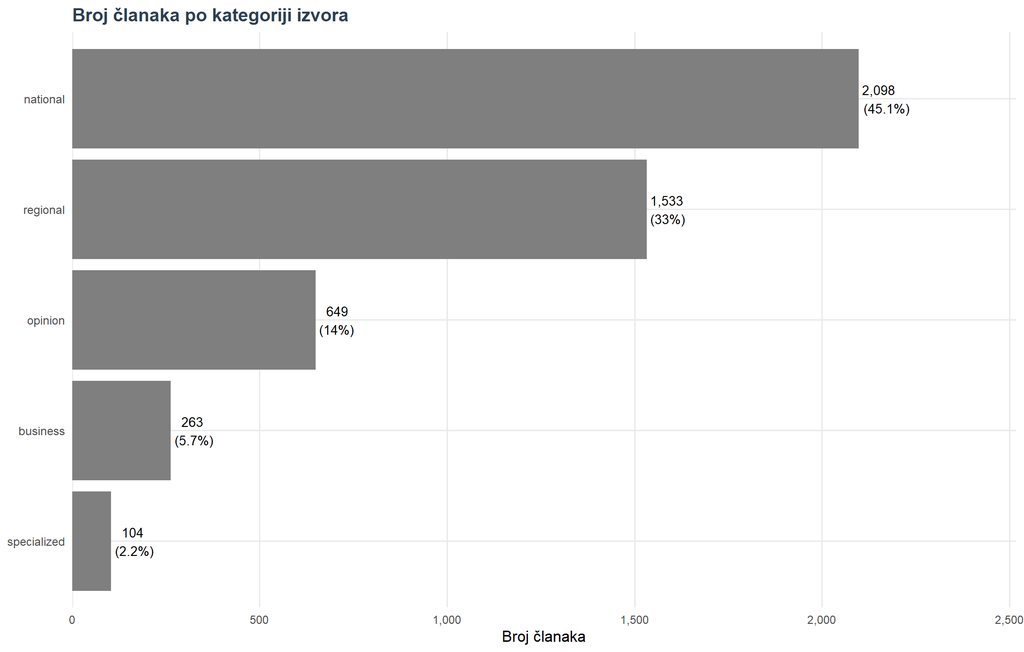

Distribucija članaka po kategorijama izvora

## 3.3 Top 20 izvora

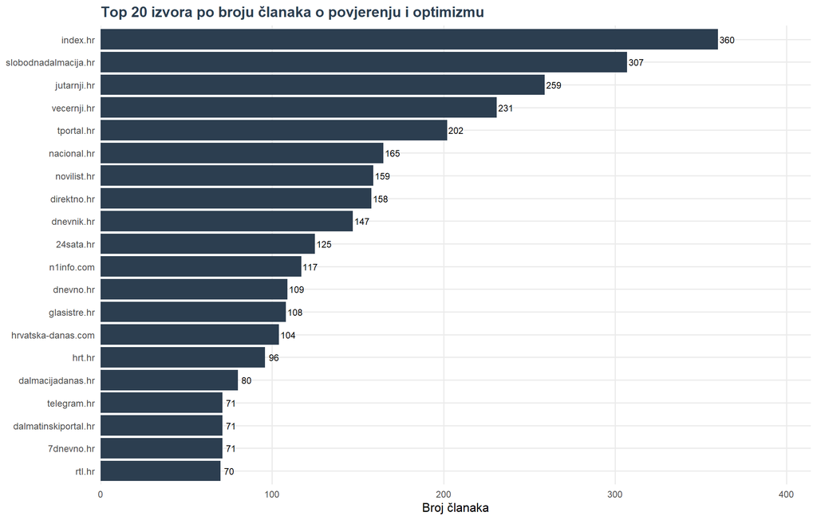

20 najaktivnijih izvora

## 3.4 Distribucija duljine teksta

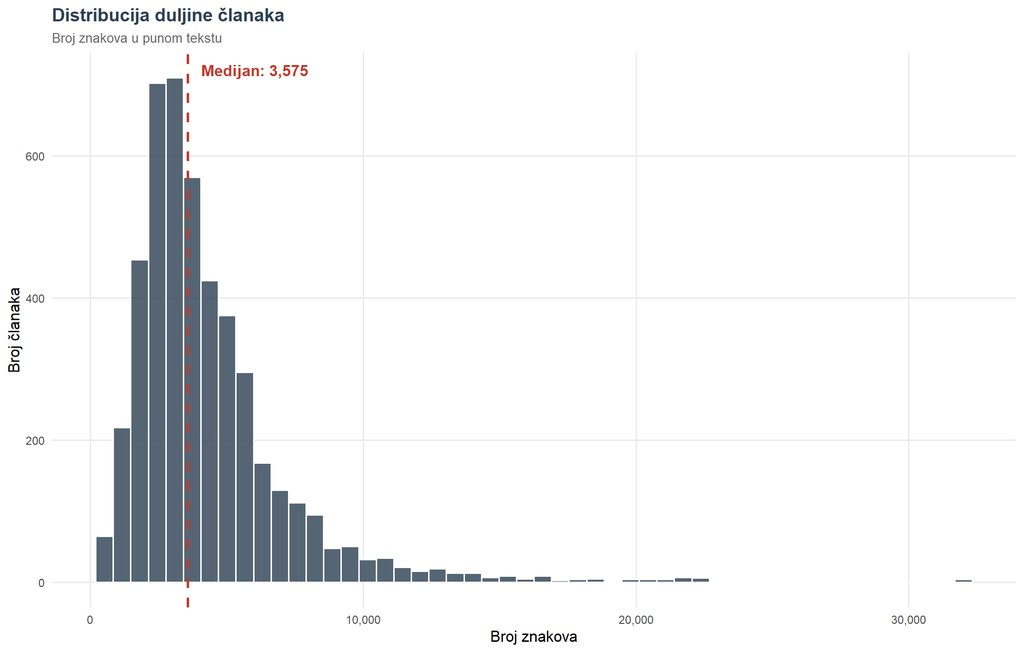

Distribucija duljine članaka

## 3.5 Dnevna frekvencija članaka

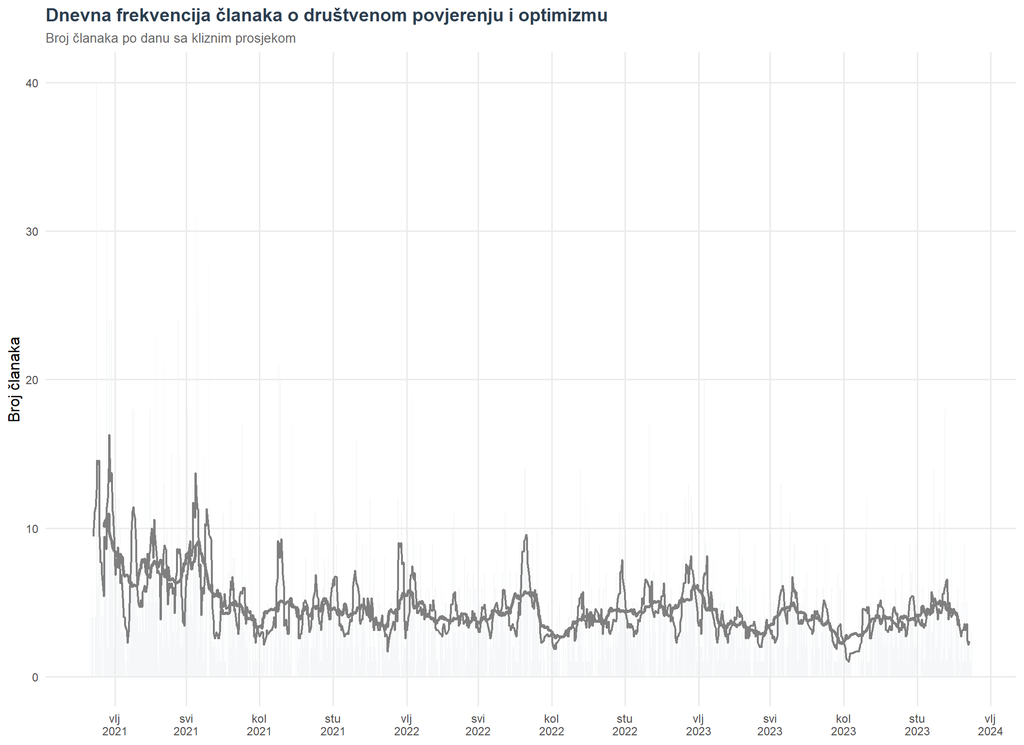

Dnevni broj članaka o povjerenju i optimizmu

## 3.6 Mjesečna dinamika

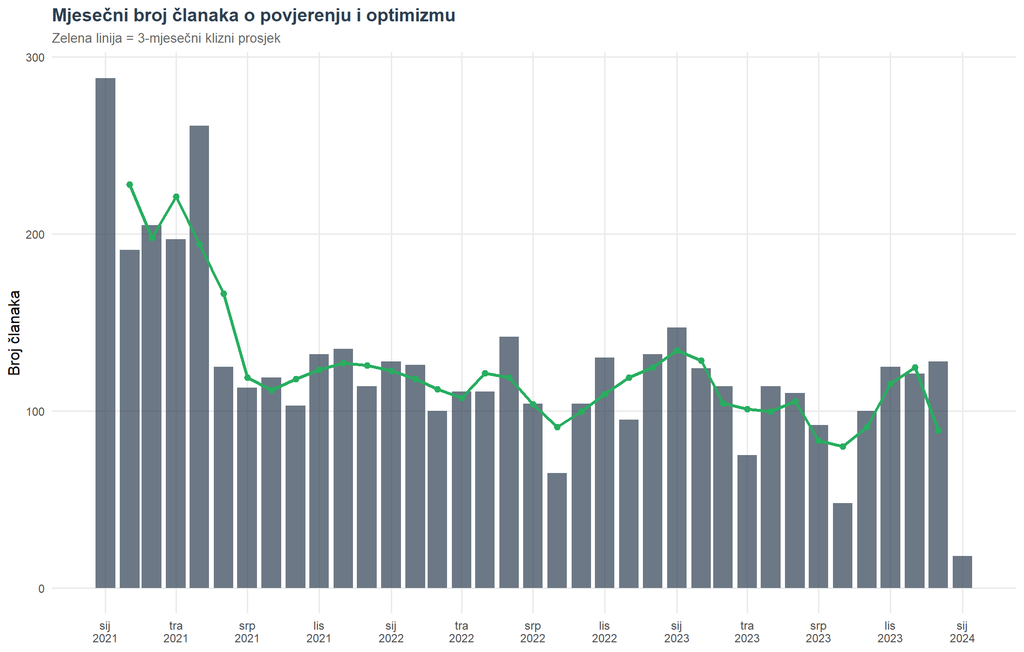

Mjesečni broj članaka

## 3.7 Godišnja usporedba

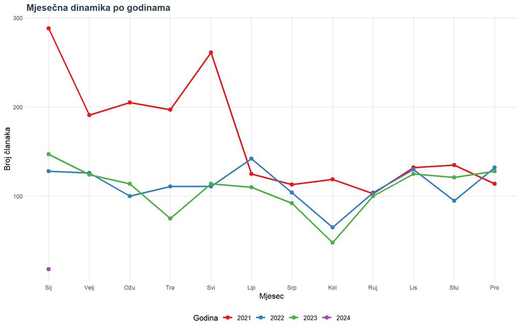

Usporedba mjesečne dinamike po godinama

# 4 Semantička taksonomija

## 4.1 Hijerarhijska struktura pojmova

Semantički rječnik se temelji na pojmovima identificiranima u procesu filtriranja članaka. Taksonomija se organizira u 12 kategorija koje obuhvaćaju različite aspekte povjerenja, zadovoljstva i društvenog raspoloženja u hrvatskom kontekstu. Pojmovi se definiraju pomoću korijena riječi (stem) kako bi se osigurala šira morfološka pokrivenost hrvatskog jezika.

**Detaljna metodologija semantičke taksonomije**

**Princip konstrukcije rječnika:**

1. Kategorije predstavljaju konceptualno različite aspekte povjerenja i optimizma
2. Regex uzorci se koriste za fleksibilno prepoznavanje morfoloških varijanti
3. Korijenski oblici osiguravaju prepoznavanje svih padežnih i glagolskih oblika

**Morfološka pokrivenost:**

Za hrvatski jezik koji ima bogatu morfologiju, koriste se korijenski oblici s opcionalnim nastavcima, alternativni oblici za palatalizaciju i wildcard znakovi koji dopuštaju varijabilnost između riječi.

**Formula za brojanje:**

$$\text{count}_{c,d} = \sum_{p \in P_c} \text{matches}(p, d)$$

gdje je $P_c$ skup regex uzoraka za kategoriju $c$, a $d$ je tekst dokumenta.

Pregled rječnika semantičkih pojmova za povjerenje i optimizam

| Kategorija | Broj pojmova | Primjeri regex uzoraka |
| --- | --- | --- |
| Opće povjerenje/nepovjerenje | 6 | povjerenj[a-zčćžšđ]*, nepovjerenj[a-zčćžšđ]* |
| Povjerenje: Vlada i Sabor | 6 | povjerenj[a-zčćžšđ]*.{0,15}vlad[a-zčćžšđ]*, povjerenj[a-zčćžšđ]*.{0,15}sabor[a-zčćžšđ]* |
| Povjerenje: Pravosuđe | 5 | povjerenj[a-zčćžšđ]*.{0,15}(sud&#124;sudstv&#124;pravosud&#124;pravosud), povjerenj[a-zčćžšđ]*.{0,15}dr[zž]avn[a-zčćžšđ]*.{0,10}odvjetni[sš]tv |
| Povjerenje: Policija i vojska | 5 | povjerenj[a-zčćžšđ]*.{0,15}policij[a-zčćžšđ]*, povjerenj[a-zčćžšđ]*.{0,15}vojsk[a-zčćžšđ]* |
| Povjerenje: Mediji | 5 | povjerenj[a-zčćžšđ]*.{0,15}medij[a-zčćžšđ]*, povjerenj[a-zčćžšđ]*.{0,15}novin[a-zčćžšđ]* |
| Povjerenje: Crkva | 3 | povjerenj[a-zčćžšđ]*.{0,15}crkv[a-zčćžšđ]*, crkv[a-zčćžšđ]*.{0,15}povjerenj |
| Povjerenje: EU | 3 | povjerenj[a-zčćžšđ]*.{0,15}(eu&#124;europsk[a-zčćžšđ]*\s+unij), (eu&#124;europsk[a-zčćžšđ]*\s+unij).{0,15}povjerenj |
| Optimizam/Pesimizam | 5 | optimiz[a-zčćžšđ]*, pesimiz[a-zčćžšđ]* |
| Zadovoljstvo životom | 6 | zadovoljstv[a-zčćžšđ]*.{0,10}[zž]ivot[a-zčćžšđ]*, nezadovoljstv[a-zčćžšđ]*.{0,10}[zž]ivot[a-zčćžšđ]* |
| Društveno raspoloženje | 4 | dru[sš]tven[a-zčćžšđ]*.{0,10}raspolo[zž]enj[a-zčćžšđ]*, raspolo[zž]enj[a-zčćžšđ]*.{0,10}(gra[dđ]an&#124;javn&#124;stanovni&#124;dru[sš]tv) |
| Strah i zabrinutost | 4 | (strah&#124;zabrinutost&#124;tjeskob)[a-zčćžšđ]*.{0,15}(gra[dđ]an&#124;javn&#124;stanovni), (gra[dđ]ani&#124;hrvati&#124;stanovni[sš]tvo).{0,15}(strahuj&#124;zabrinut) |
| Budućnost i perspektive | 4 | (o[cč]ekivanj&#124;izgled&#124;perspektiv)[a-zčćžšđ]*.{0,15}(gra[dđ]an&#124;hrvatsk), budu[cć]nost[a-zčćžšđ]*.{0,10}(hrvatsk&#124;na[sš]) |

## 4.2 Brojanje semantičkih pojmova

## 4.3 Mjesečna agregacija semantičkih pojmova

## 4.4 Vizualizacija semantičkih kategorija kroz vrijeme

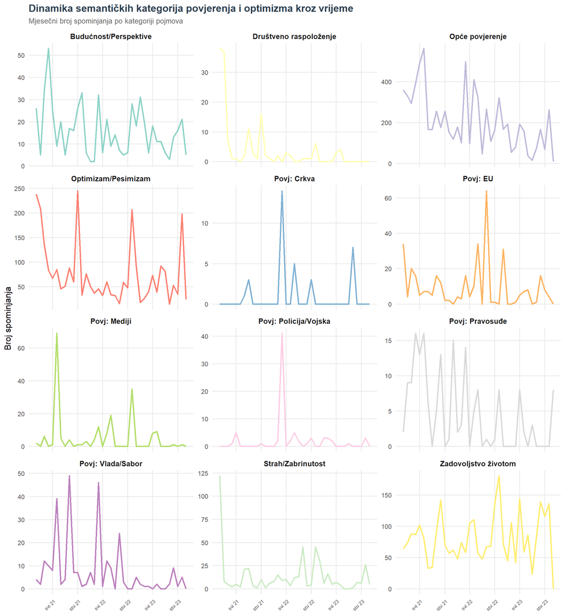

Dinamika semantičkih kategorija kroz vrijeme

# 5 Konstrukcija indeksa

### 5.0.1 General Trust Index (GTI)

GTI kvantificira intenzitet diskursa o povjerenju i nepovjerenju u općem smislu, bez specifičnog institucionalnog fokusa. Konstrukcija se temelji na prebrojavanju pojavljivanja korijena riječi koje signaliziraju povjerenje ili nepovjerenje, kao što su povjerenj, nepovjerenj, vjeruj i slično. Suma tih pojavljivanja normalizira se brojem članaka kako bi se dobila prosječna mjesečna frekvencija pojmova povjerenja. Rezultat se skalira na raspon 0 do 100 standardnom normalizacijom. Povišene vrijednosti GTI indeksa indiciraju razdoblja intenzivnog medijskog diskursa o temi povjerenja.

**Detaljna metodologija GTI indeksa**

**Formula:**

$$\text{GTI}_t = \text{normalize}_{0-100}\left(\frac{\text{count}_{povjerenje\_opce,t}}{N_t}\right)$$

**Uključeni pojmovi:** povjerenje, nepovjerenje, vjeruju/ne vjeruju, rast/pad/gubitak povjerenja, međuljudsko povjerenje

**Normalizacija (min-max):**

$$X_{norm} = \frac{X - \min(X)}{\max(X) - \min(X)} \times 100$$

### 5.0.2 Political Trust Index (PTI)

PTI prati intenzitet diskursa o povjerenju u političke institucije, uključujući Vladu, Sabor, predsjednika i političare općenito. Indeks se konstruira identifikacijom kolokacija pojmova povjerenja s političkim akterima i institucijama. Normalizacija brojem članaka osigurava usporedivost kroz različite periode medijske aktivnosti. Vrhovi PTI indeksa koincidiraju s političkim krizama, izbornim ciklusima i skandalima koji utječu na percepciju političkog sustava.

**Detaljna metodologija PTI indeksa**

**Formula:**

$$\text{PTI}_t = \text{normalize}_{0-100}\left(\frac{\text{count}_{povjerenje\_vlada,t}}{N_t}\right)$$

**Uključeni pojmovi:** povjerenje u vladu, povjerenje u Sabor, povjerenje u predsjednika, (ne)povjerenje u političare

### 5.0.3 Judicial Trust Index (JTI)

JTI mjeri povjerenje u pravosuđe i pravni sustav. Indeks obuhvaća reference na sudove, državno odvjetništvo, USKOK i pravosuđe općenito u kontekstu povjerenja. Konstrukcija prati istu metodologiju normalizacije kao ostali indeksi. Varijacije JTI indeksa reflektiraju medijsku percepciju efikasnosti i nepristranosti pravosudnog sustava.

**Detaljna metodologija JTI indeksa**

**Formula:**

$$\text{JTI}_t = \text{normalize}_{0-100}\left(\frac{\text{count}_{povjerenje\_pravosude,t}}{N_t}\right)$$

**Uključeni pojmovi:** povjerenje u sudove, pravosuđe, državno odvjetništvo, USKOK

### 5.0.4 Security Trust Index (STI)

STI prati povjerenje u sigurnosne institucije, primarno policiju i vojsku. Indeks identificira kolokacije pojmova povjerenja sa sigurnosnim aparatom države. Stabilne vrijednosti STI indeksa tradicionalno ukazuju na visoku razinu povjerenja građana u sigurnosne institucije, dok nagle promjene mogu signalizirati kontroverzne slučajeve ili krize.

**Detaljna metodologija STI indeksa**

**Formula:**

$$\text{STI}_t = \text{normalize}_{0-100}\left(\frac{\text{count}_{povjerenje\_sigurnost,t}}{N_t}\right)$$

**Uključeni pojmovi:** povjerenje u policiju, vojsku, oružane snage

### 5.0.5 Media Trust Index (MTI)

MTI mjeri intenzitet diskursa o povjerenju u medije. Indeks obuhvaća reference na novine, televiziju i medije općenito u kontekstu (ne)povjerenja. Pad MTI indeksa može signalizirati eroziju povjerenja u medijske institucije, dok rast može ukazivati na pojačanu debatu o ulozi medija u društvu.

**Detaljna metodologija MTI indeksa**

**Formula:**

$$\text{MTI}_t = \text{normalize}_{0-100}\left(\frac{\text{count}_{povjerenje\_mediji,t}}{N_t}\right)$$

**Uključeni pojmovi:** povjerenje u medije, novine, televiziju

### 5.0.6 Religious Trust Index (RTI)

RTI prati povjerenje u Crkvu i vjerske institucije. Indeks identificira kolokacije pojmova povjerenja s crkvenim i religijskim referentima. Dinamika RTI indeksa reflektira ulogu Crkve u javnom diskursu i percepciju njenog društvenog utjecaja.

**Detaljna metodologija RTI indeksa**

**Formula:**

$$\text{RTI}_t = \text{normalize}_{0-100}\left(\frac{\text{count}_{povjerenje\_crkva,t}}{N_t}\right)$$

**Uključeni pojmovi:** povjerenje u Crkvu, katoličke i vjerske institucije

### 5.0.7 EU Trust Index (ETI)

ETI mjeri povjerenje u Europsku uniju i europske institucije. Indeks koristi podatke iz Eurobarometra i reference na EU u kontekstu povjerenja. Dinamika ETI indeksa prati europske integracije i percepciju EU članstva u hrvatskom javnom diskursu.

**Detaljna metodologija ETI indeksa**

**Formula:**

$$\text{ETI}_t = \text{normalize}_{0-100}\left(\frac{\text{count}_{povjerenje\_eu,t}}{N_t}\right)$$

**Uključeni pojmovi:** povjerenje u EU, europske institucije, Eurobarometar

### 5.0.8 Optimism-Pessimism Index (OPI)

OPI mjeri balans između optimizma i pesimizma u medijskom diskursu o društvenom raspoloženju. Indeks kombinira reference na optimizam i pesimizam građana, omogućujući praćenje kolektivnog sentimenta. Visoke vrijednosti OPI indeksa ukazuju na intenzivan diskurs o kolektivnom raspoloženju, bez nužne implikacije o smjeru tog raspoloženja.

**Detaljna metodologija OPI indeksa**

**Formula:**

$$\text{OPI}_t = \text{normalize}_{0-100}\left(\frac{\text{count}_{optimizam\_pesimizam,t}}{N_t}\right)$$

**Uključeni pojmovi:** optimizam, pesimizam, optimističan/pesimističan, kolektivno raspoloženje

### 5.0.9 Life Satisfaction Index (LSI)

LSI prati intenzitet diskursa o kvaliteti života i zadovoljstvu životom. Indeks obuhvaća reference na životni standard, životne uvjete i indekse dobrobiti. Povišene vrijednosti LSI indeksa indiciraju pojačan interes za teme kvalitete života, često u kontekstu komparativnih analiza ili istraživanja.

**Detaljna metodologija LSI indeksa**

**Formula:**

$$\text{LSI}_t = \text{normalize}_{0-100}\left(\frac{\text{count}_{zadovoljstvo\_zivotom,t}}{N_t}\right)$$

**Uključeni pojmovi:** zadovoljstvo životom, kvaliteta života, životni standard, životni uvjeti, indeks dobrobiti/blagostanja/sreće

### 5.0.10 Social Mood Index (SMI)

SMI mjeri opće društveno raspoloženje percipirano kroz medijski diskurs. Indeks identificira reference na kolektivnu atmosferu, javno raspoloženje i društvenu klimu. Varijacije SMI indeksa reflektiraju percepciju društvene kohezije i općeg stanja u društvu.

**Detaljna metodologija SMI indeksa**

**Formula:**

$$\text{SMI}_t = \text{normalize}_{0-100}\left(\frac{\text{count}_{drustveno\_raspolozenje,t}}{N_t}\right)$$

**Uključeni pojmovi:** društveno raspoloženje, javna atmosfera, opće raspoloženje

### 5.0.11 Fear-Worry Index (FWI)

FWI kvantificira intenzitet diskursa o kolektivnom strahu i zabrinutosti građana. Indeks identificira reference na strahove, tjeskobe i zabrinutosti u kontekstu javnog mnijenja. Vrhovi FWI indeksa koincidiraju s kriznim razdobljima poput pandemije, rata ili ekonomskih šokova koji generiraju kolektivnu anksioznost.

**Detaljna metodologija FWI indeksa**

**Formula:**

$$\text{FWI}_t = \text{normalize}_{0-100}\left(\frac{\text{count}_{strah\_zabrinutost,t}}{N_t}\right)$$

**Uključeni pojmovi:** strah/zabrinutost/tjeskoba građana, kolektivni strah

### 5.0.12 Future Outlook Index (FOI)

FOI mjeri intenzitet diskursa o perspektivama i očekivanjima za budućnost. Indeks obuhvaća reference na izglede, perspektive i nadanja građana. Dinamika FOI indeksa reflektira kolektivnu orijentaciju prema budućnosti i percepciju razvojnih mogućnosti.

**Detaljna metodologija FOI indeksa**

**Formula:**

$$\text{FOI}_t = \text{normalize}_{0-100}\left(\frac{\text{count}_{buducnost\_perspektive,t}}{N_t}\right)$$

**Uključeni pojmovi:** očekivanja, izgledi, perspektive, nada za budućnost

### 5.0.13 Composite Trust Index (CTI)

CTI predstavlja kompozitni indeks koji agregira svih 12 specijaliziranih indeksa u jedinstvenu mjeru intenziteta diskursa o povjerenju i optimizmu. Konstrukcija se temelji na jednostavnom prosjeku normaliziranih vrijednosti svih komponenti. CTI pruža holističku sliku medijske percepcije društvenog povjerenja i raspoloženja.

**Detaljna metodologija CTI indeksa**

**Formula:**

$$\text{CTI}_t = \frac{1}{12} \sum_{i=1}^{12} \text{Indeks}_{i,t}$$

**Interpretacija vrijednosti:**

- 0-25: Niska razina diskursa o temi
- 25-50: Umjerena razina
- 50-75: Visoka razina
- 75-100: Vrlo visoka razina (intenzivna medijska pozornost)

## 5.1 Opis indeksa

Pregled konstruiranih indeksa

| Indeks | Naziv | Opis |
| --- | --- | --- |
| GTI | General Trust Index | Opći diskurs o povjerenju/nepovjerenju |
| PTI | Political Trust Index | Povjerenje u Vladu, Sabor, političare |
| JTI | Judicial Trust Index | Povjerenje u pravosuđe i sudove |
| STI | Security Trust Index | Povjerenje u policiju i vojsku |
| MTI | Media Trust Index | Povjerenje u medije |
| RTI | Religious Trust Index | Povjerenje u Crkvu |
| ETI | EU Trust Index | Povjerenje u EU institucije |
| OPI | Optimism-Pessimism Index | Diskurs o optimizmu i pesimizmu |
| LSI | Life Satisfaction Index | Kvaliteta života i zadovoljstvo |
| SMI | Social Mood Index | Opće društveno raspoloženje |
| FWI | Fear-Worry Index | Kolektivni strah i zabrinutost |
| FOI | Future Outlook Index | Perspektive i očekivanja za budućnost |
| CTI | Composite Trust Index | Kompozitni prosjek svih indeksa |

# 6 Vizualizacija indeksa

## 6.1 Glavni indeksi

### 6.1.1 Composite Trust Index (CTI)

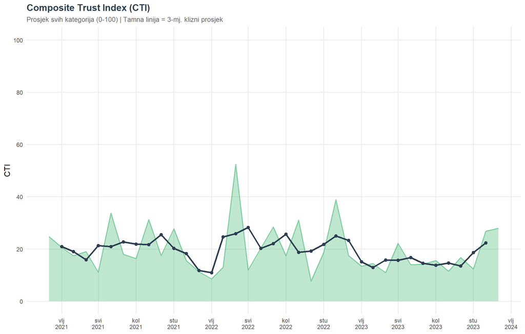

Composite Trust Index (CTI)

### 6.1.2 General Trust Index (GTI)

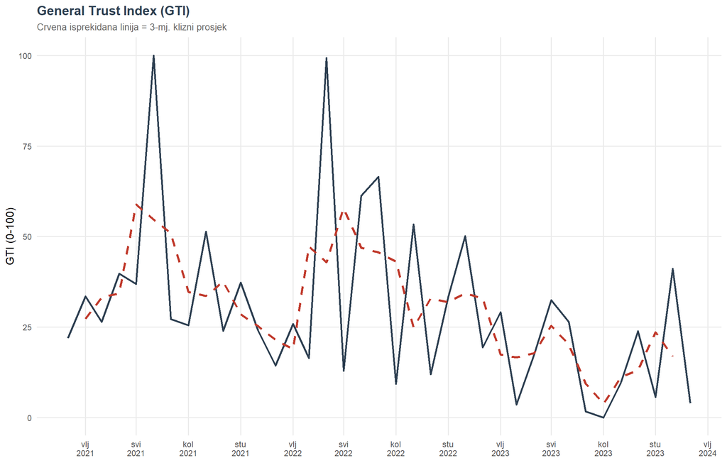

General Trust Index (GTI)

## 6.2 Institucionalni indeksi povjerenja

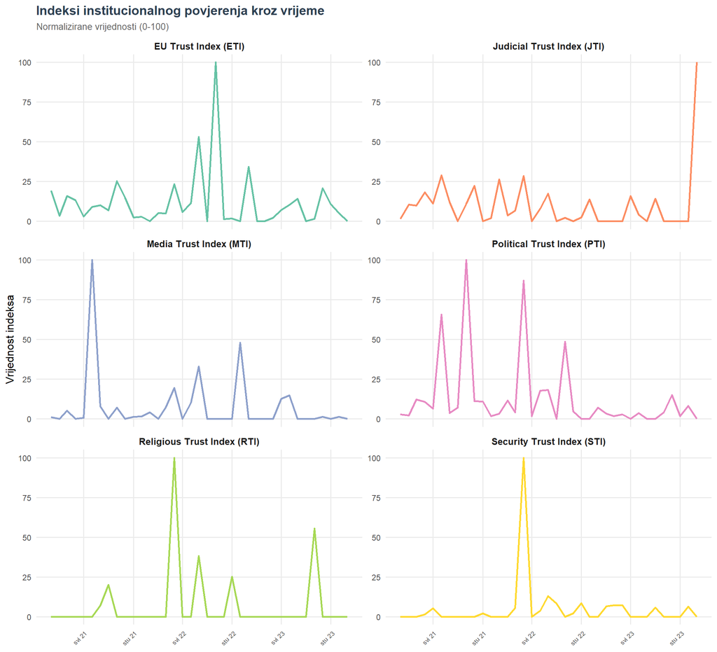

Indeksi institucionalnog povjerenja (PTI, JTI, STI, MTI, RTI, ETI)

## 6.3 Indeksi raspoloženja i perspektiva

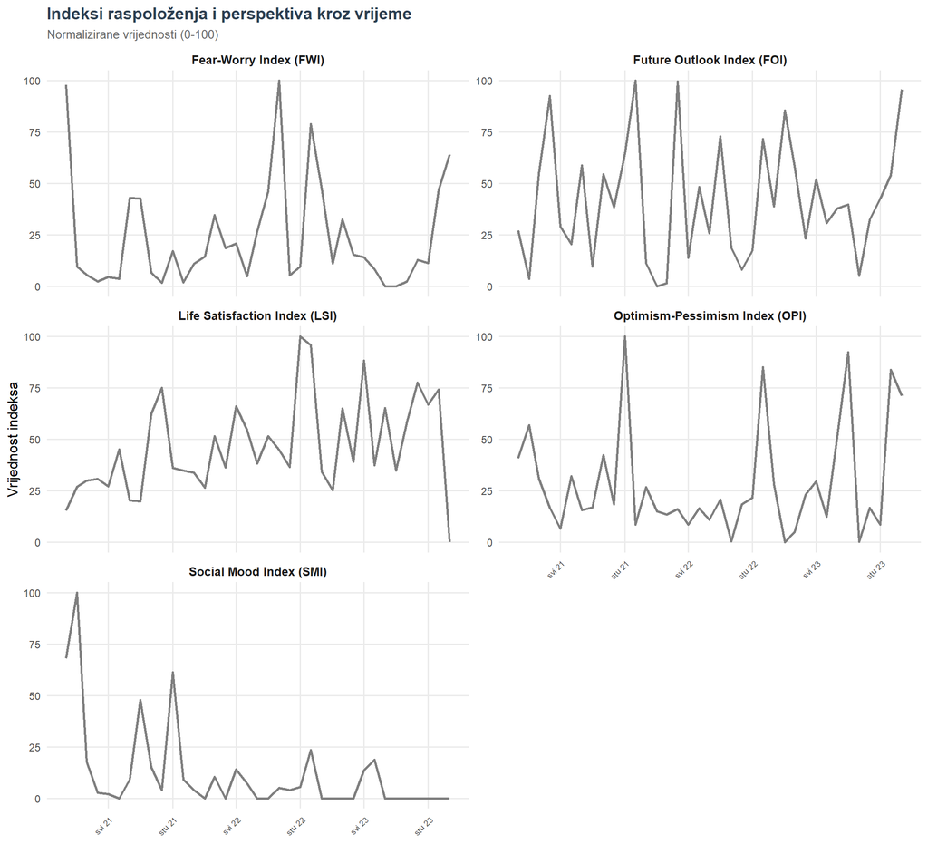

Indeksi raspoloženja i perspektiva (OPI, LSI, SMI, FWI, FOI)

## 6.4 Usporedba svih indeksa

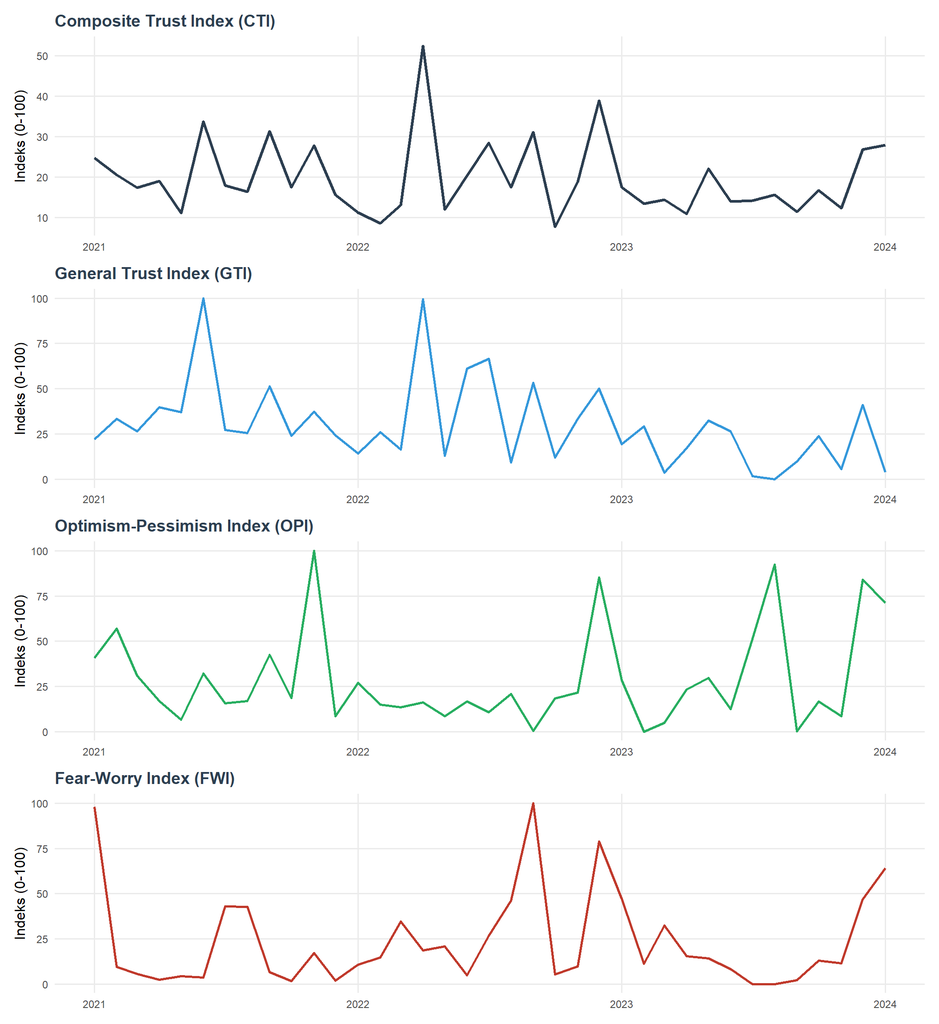

Svi indeksi povjerenja i optimizma

# 7 Sektorska analiza

## 7.1 Dinamika po sektorima

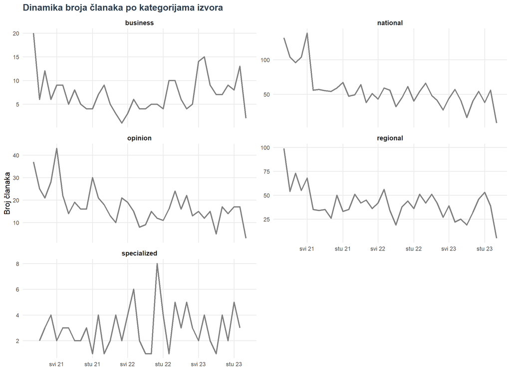

Dinamika po kategorijama izvora

## 7.2 Heatmapa sektorske aktivnosti

[figure not shown]

Heatmapa intenziteta diskursa po sektorima

## 7.3 Korelacijska struktura

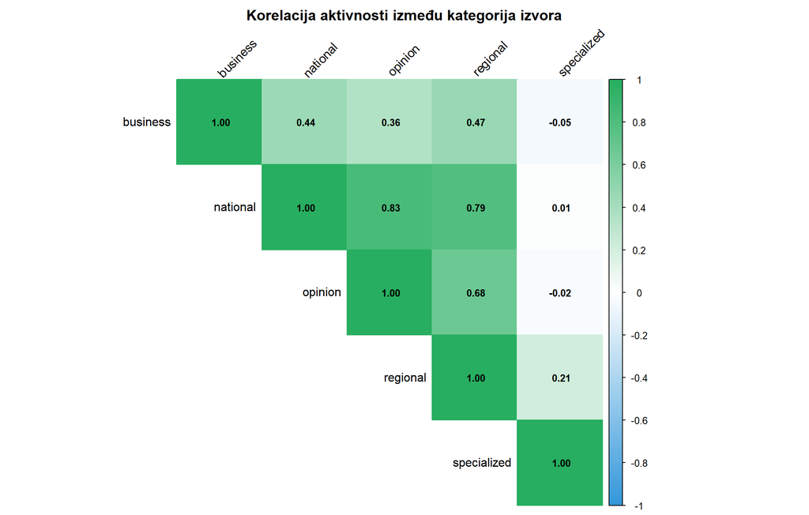

Korelacija između kategorija izvora

# 8 Sentiment analiza

## 8.1 Komponente sentimenta

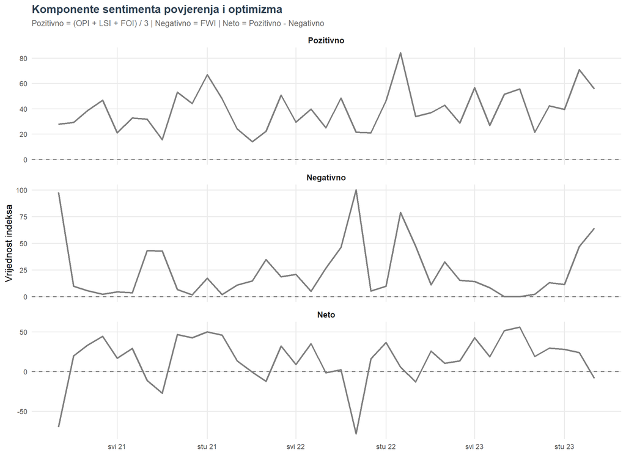

Komponente sentimenta kroz vrijeme

## 8.2 Neto sentiment ratio

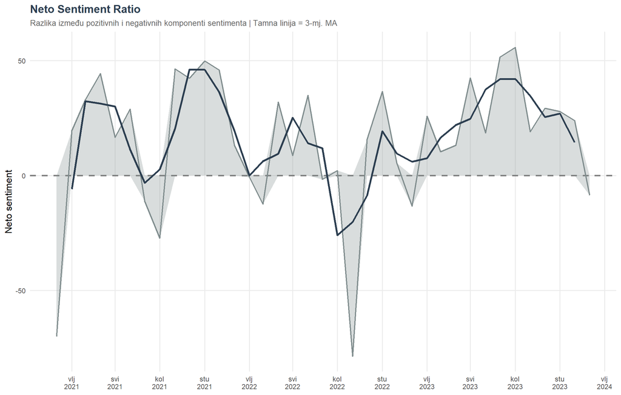

Neto sentiment ratio kroz vrijeme

# 9 Volatilnost i momentum

## 9.1 Konstrukcija volatilnosti i momentuma

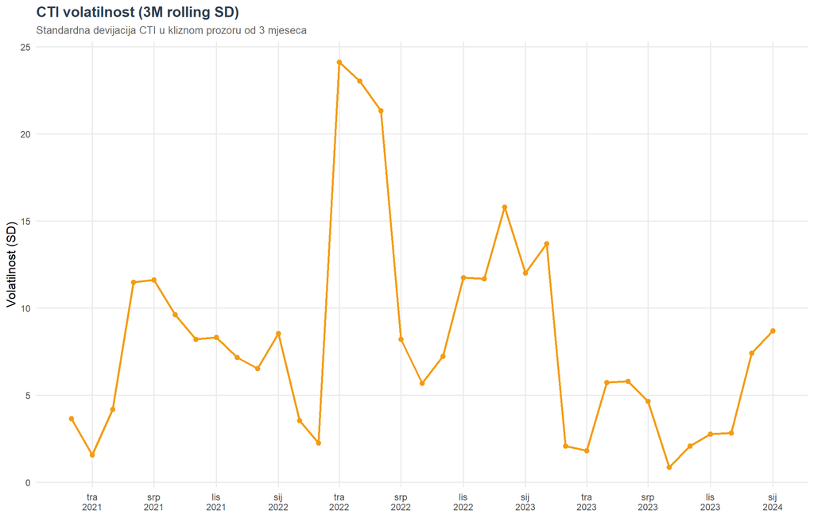

Volatilnost CTI (3M rolling SD)

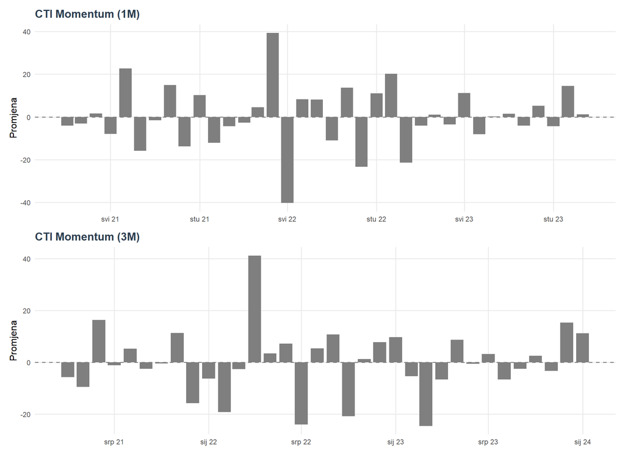

Momentum CTI

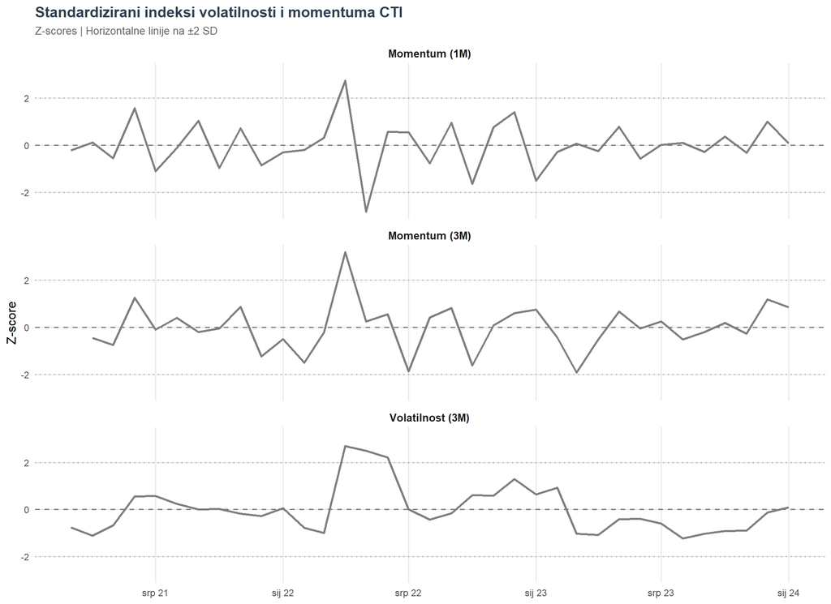

Standardizirani indeksi volatilnosti i momentuma

# 10 Koncentracija tema

## 10.1 Konstrukcija mjera koncentracije

**Interpretacija HHI indeksa**

Herfindahl-Hirschman Index (HHI) mjeri koncentraciju aktivnosti među kategorijama. Niže vrijednosti HHI ukazuju na ravnomjerniju distribuciju tema, dok više vrijednosti signaliziraju dominaciju pojedinih kategorija u medijskom diskursu.

**Formula:**

$$\text{HHI}_t = \sum_{i=1}^{n} s_{i,t}^2$$

gdje je $s_{i,t}$ udio kategorije $i$ u ukupnom broju spominjanja u mjesecu $t$.

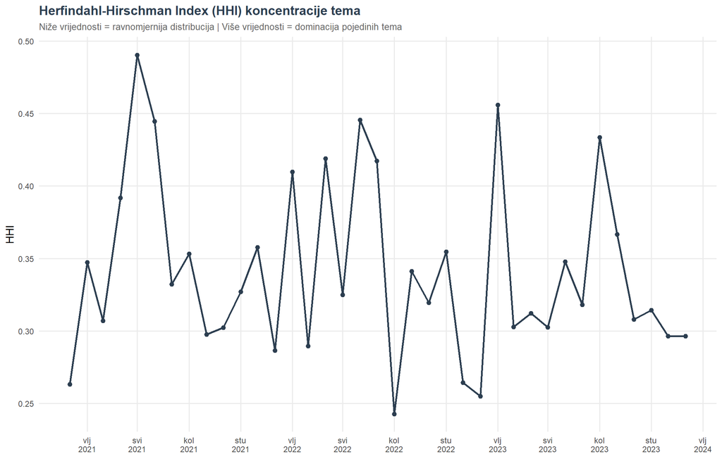

Herfindahl-Hirschman Index koncentracije tema

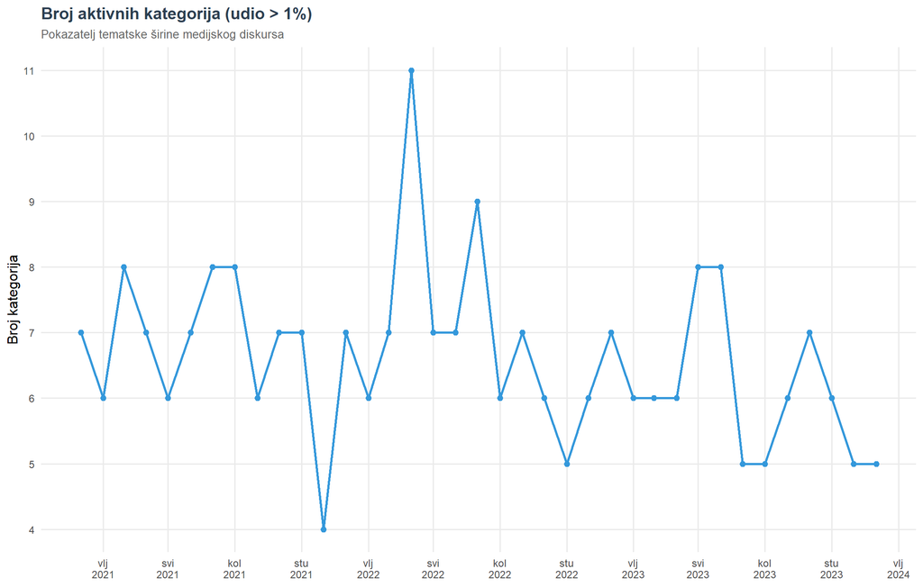

Broj aktivnih kategorija kroz vrijeme

# 11 Korelacije između indeksa

## 11.1 Korelacijska matrica indeksa

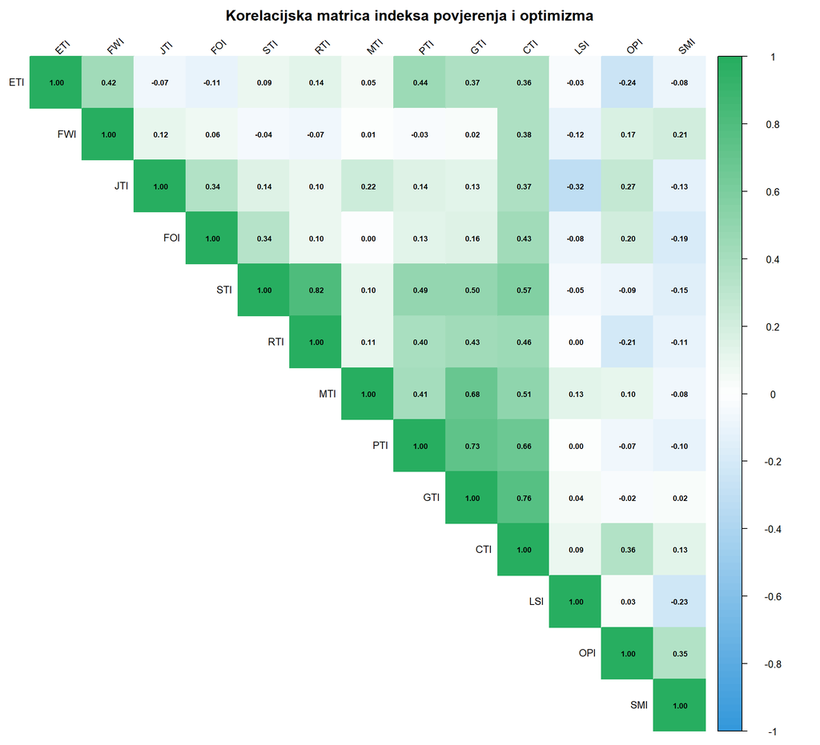

Korelacijska matrica indeksa povjerenja i optimizma

## 11.2 Korelacijska tablica

Korelacije pojedinačnih indeksa s Composite Trust Index

| Indeks | Korelacija s CTI |
| --- | --- |
| GTI | 0.761 |
| PTI | 0.661 |
| STI | 0.571 |
| MTI | 0.511 |
| RTI | 0.460 |
| FOI | 0.433 |
| FWI | 0.379 |
| JTI | 0.368 |
| ETI | 0.363 |
| OPI | 0.358 |
| SMI | 0.131 |
| LSI | 0.087 |

# 12 Export

# 13 Sažetak

Sažetak ključnih nalaza analize

| Nalaz | Vrijednost |
| --- | --- |
| Ukupno analiziranih članaka | 4,647 |
| Vremenski raspon analize | 01/2021 - 01/2024 |
| Broj izvora | 111 |
| Vrh CTI indeksa | travanj 2022 |
| Vrijednost vrha | 52.4 |
| Dominantna kategorija | Life Satisfaction Index |
| Prosječna vrijednost | 46.7 |
| Prosječni CTI | 19.7 |
| Standardna devijacija CTI | 9.3 |

*Izvještaj generiran: 2026-01-02 13:54:40.700018*

*GIMES Research | Analiza medijske pokrivenosti društvenog povjerenja i optimizma v2.0*